# Track simulation

# Home range behavior

To model home range behavior, i.e. not necessarily a random walk but a pattern that results in site fidelity we can use a biased Ohrnstein Uhlenbeck process, for example like the model used in Breed et al. (2017). The direction is biased towards a home range center, and the attraction effect is stronger the further you are from the center.

$$x_{t+dt}|x_t\sim x_t+\omega(\mu-x_t)dt+\mathcal{N}(0, \sigma dt)$$

This results in a 2D probability density function of the form

$$x_{t+dt}|x_t\sim\mathcal{N}(\mathbf{\mu_i}+e^{\mathbf\omega_idt}(\mathbf{x_t-\mu_i}),\Sigma_i-e^{\mathbf\omega_idt}\Sigma_ie^{\mathbf\omega_i'dt})$$

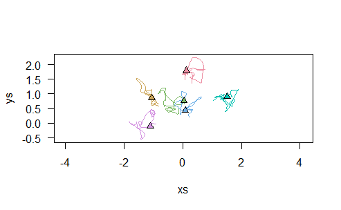

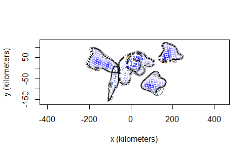

```r
with(list(nind = 6,
          nsteps = 100,
          sigmastep = 0.1,
          omega = 0.05,
          sigma0 = 1,
          phi = 1.2,
          dscalar = 1e4), {
            xs = replicate(nind, numeric(nsteps))
            ys = replicate(nind, numeric(nsteps))
            hrcenters = matrix(rnorm(nind*2, sd = sigma0), ncol = 2)
            # smoother matrix
            H_inl <- outer(seq_len(nsteps),seq_len(nsteps), \(x,y) abs(x-y)/phi*besselK(abs(x-y)/phi, nu = 1))
            diag(H_inl) <- 1
            H_inl <- H_inl/rowSums(H_inl)
            for (s in seq_len(nind)) {
              x <- y <- numeric(nsteps)
              x[1] <- mux <- hrcenters[s,1]
              y[1] <- muy <- hrcenters[s,2]
              xnoise = rnorm(nsteps, sd = sigmastep)
              ynoise = rnorm(nsteps, sd = sigmastep)
              # take successive steps
              for(i in seq_len(nsteps-1)) {
                x[i+1] = x[i]+omega*(mux-x[i])+xnoise[i]
                y[i+1] = y[i]+omega*(muy-y[i])+ynoise[i]
              }
              xs[,s] = x
              ys[,s] = y
            }
            # Smooth the trajectories
            xs <- apply(xs, 2, "%*%", H_inl)
            ys <- apply(ys, 2, "%*%", H_inl)

            # scale position and displacement
            xs <- xs
            ys <- ys
            # Plot
            plot(xs,ys,type = "n", asp=1, las = 1)
            sapply(seq_len(nind), \(x) lines(xs[,x],ys[,x],col = hcl.colors(nind, "Set 2")[x]))
            points(hrcenters, bg = hcl.colors(nind, "Set 2"), pch  = 24)



            ### Create telemetry object and fit a CTMM model
            tel_data <- as.telemetry(data.frame(individual.local.identifier = rep(1:nind, each = nsteps),
                                                timestamp = as.POSIXct(3600*seq_len(nsteps), origin = "2020-01-01 8:00"),
                                                location.long = as.numeric(ys),
                                                location.lat = as.numeric(xs)))
            ctmmfits <- lapply(tel_data, ctmm.fit)

            ## Estimate the AKDE UDs
            akdes <- akde(tel_data, ctmmfits)
            plot(akdes)

            ## Get the overlap area
            cdes <- list()
            for (i in 1:nind) {
              for(j in 1:nind) {
                if (i==j) next
                cde <- encounter(list(akdes[[i]], akdes[[j]]))
                plot(cde)
                cdes[[paste(i,j)]] <- cde
              }
            }
          })
```